# Week 5, Dimensionality reduction techniques

This week’s exercise is about reducing dimensions. Tasks include:

- Data exploration
- Standardization
- Principal Component Analysis (PCA)
- Bonus-task: horrible nightmare with package dependency hell
- Multiple Correspondence Analysis (MCA)

## 0. Starting routines and getting to know data

Setting working path, loading library and data set.

```r
#Setting working path
setwd("/home/ls/R/projekteja/IODS-project/")

#Reading dataset from the file
human <- read.table("./data/human.rData")
#n=155, 8 vars.
```

## 1. Graphical overview

Showing a graphical overview of the data and summaries of the variables in the data.

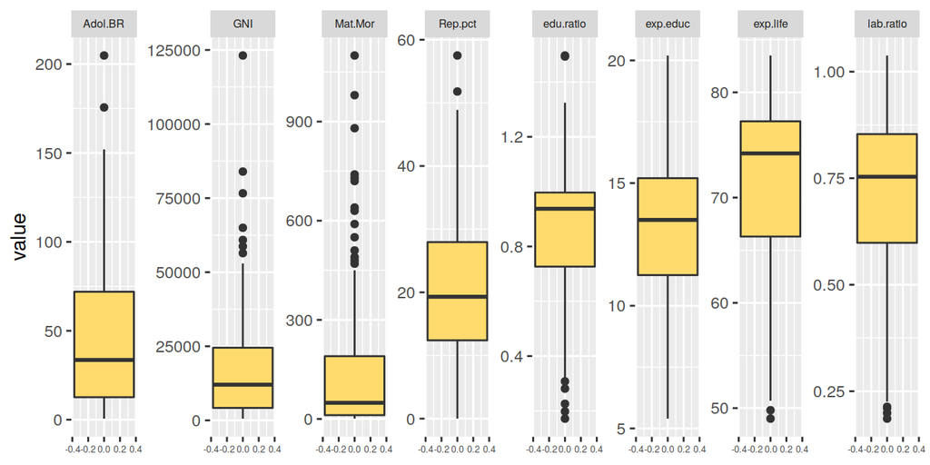

```r
library(GGally)   #for ggpairs
library(ggplot2)  #for ggplot
library(corrplot) #for corrplot
library(tidyr)    #for gather

cols <- colnames(human)

#Boxplots for each variable
gather(human[cols]) %>% ggplot(aes(y=value)) +
  facet_wrap("key", scales = "free", ncol=8) +
  geom_boxplot(fill="#FFDB6D") +
  theme(strip.text.x=element_text(size = 6),
        axis.text.x=element_text(size = 5))
```

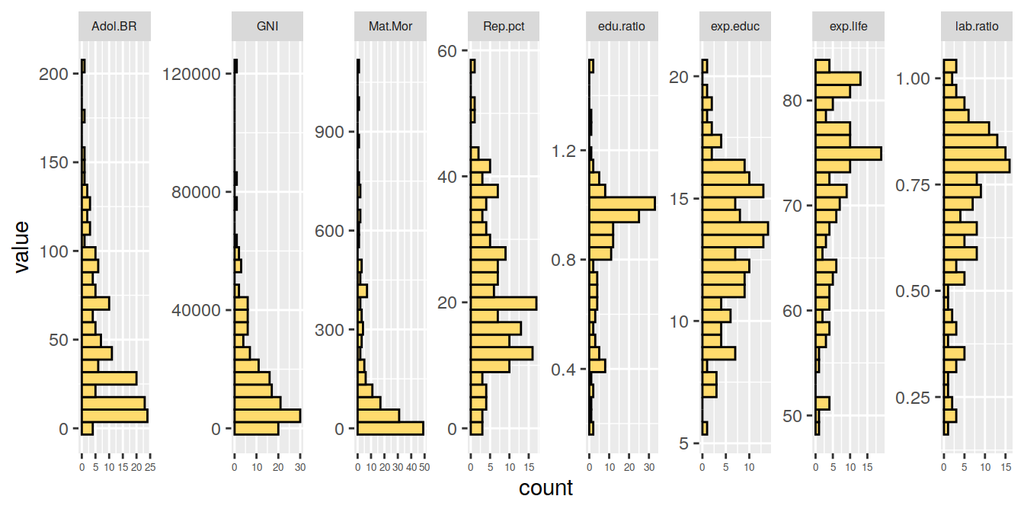

```r
#Histogram for each variable
gather(human[cols]) %>% ggplot(aes(y=value)) +
  facet_wrap("key", scales = "free", ncol=8) +
  geom_histogram(fill="#FFDB6D",col="black") +
  theme(strip.text.x=element_text(size = 6),
        axis.text.x=element_text(size = 5))
```

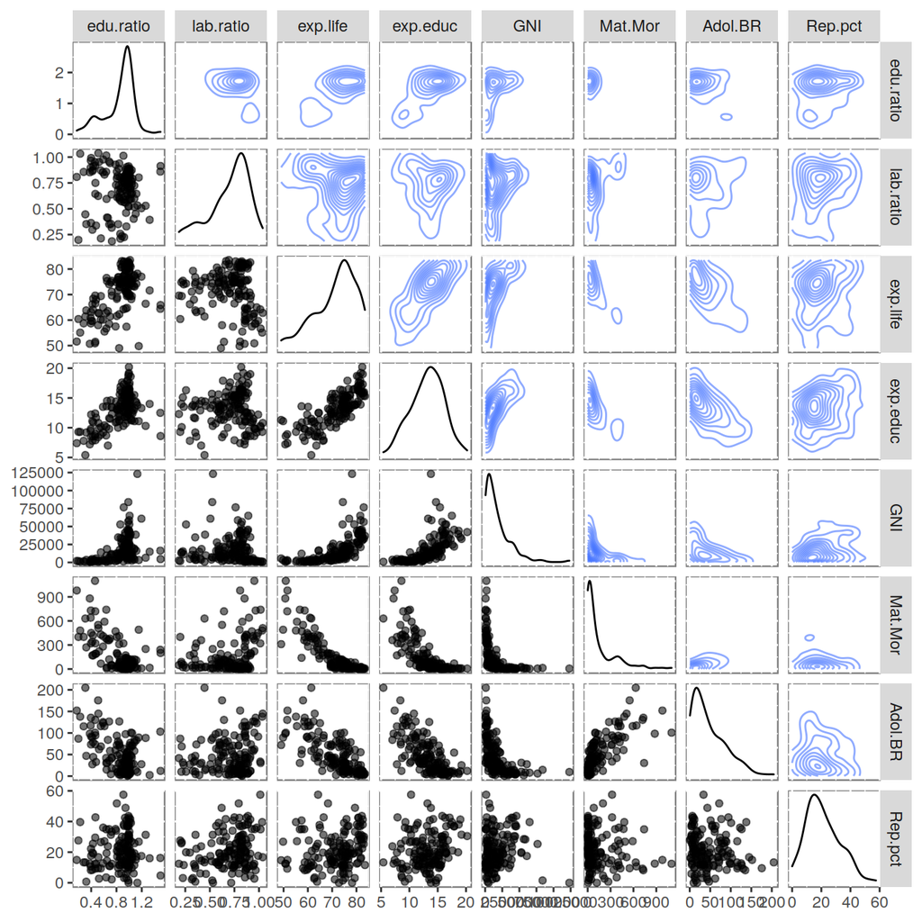

```r
#Pairwise and single distributions with density lines
par(col.sub="white")
ggpairs(human, aes(alpha=0.3),
        upper=list(continuous="density"),
        lower=list(combo=wrap("facethist"))) +
   theme(panel.background=element_rect(fill="white", colour="grey50"))
```

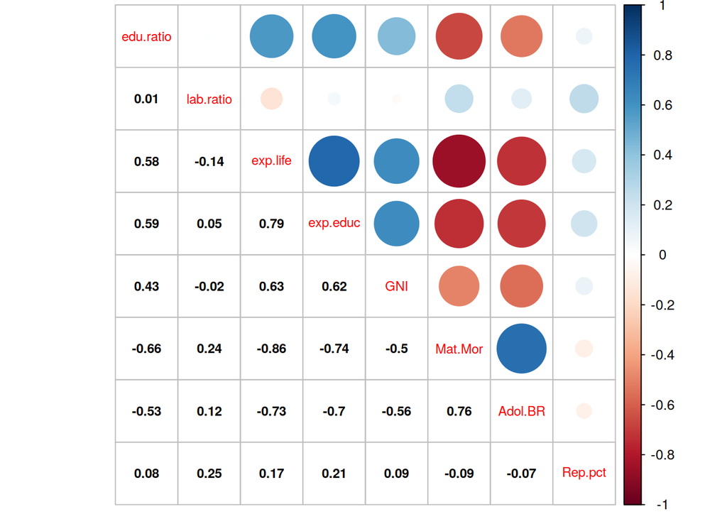

```r
#Correlation plots
cor_matrix<-cor(human)
corrplot.mixed(cor_matrix,
               tl.cex=0.75, number.cex=0.75, number.digits=2, lower.col="black")
```

```r
summary(human)
```

```
##    edu.ratio        lab.ratio         exp.life        exp.educ
##  Min.   :0.1717   Min.   :0.1857   Min.   :49.00   Min.   : 5.40
##  1st Qu.:0.7264   1st Qu.:0.5984   1st Qu.:66.30   1st Qu.:11.25
##  Median :0.9375   Median :0.7535   Median :74.20   Median :13.50
##  Mean   :0.8529   Mean   :0.7074   Mean   :71.65   Mean   :13.18
##  3rd Qu.:0.9968   3rd Qu.:0.8535   3rd Qu.:77.25   3rd Qu.:15.20
##  Max.   :1.4967   Max.   :1.0380   Max.   :83.50   Max.   :20.20
##       GNI            Mat.Mor          Adol.BR          Rep.pct
##  Min.   :   581   Min.   :   1.0   Min.   :  0.60   Min.   : 0.00
##  1st Qu.:  4198   1st Qu.:  11.5   1st Qu.: 12.65   1st Qu.:12.40
##  Median : 12040   Median :  49.0   Median : 33.60   Median :19.30
##  Mean   : 17628   Mean   : 149.1   Mean   : 47.16   Mean   :20.91
##  3rd Qu.: 24512   3rd Qu.: 190.0   3rd Qu.: 71.95   3rd Qu.:27.95
##  Max.   :123124   Max.   :1100.0   Max.   :204.80   Max.   :57.50
```

Correlations (Pearson’s $r$) between variables are mostly high or moderate, expect between **lab.ratio**; *Labour female/male ratio* and other variables, and between **Rep.pct**; *Female % representation in Parliament* and other variables. Some of the coefficients are indicating positive correlation, others negative one (please see corr.plot below for details).

## 2. Principal component analysis (PCA)

Performing principal component analysis (PCA) on the not standardized human data. Showing the variability captured by the principal components. Drawing a biplot displaying the observations by the first two principal components (PC1 coordinate in x-axis, PC2 coordinate in y-axis), along with arrows representing the original variables.

```r
# perform principal component analysis (with the SVD method)
pca_human <- prcomp(human)

#PCA results in nutshell
summary(pca_human)
```

```
## Importance of components:
##                              PC1      PC2   PC3   PC4   PC5   PC6    PC7    PC8
## Standard deviation     1.854e+04 185.5219 25.19 11.45 3.766 1.566 0.1912 0.1591
## Proportion of Variance 9.999e-01   0.0001  0.00  0.00 0.000 0.000 0.0000 0.0000
## Cumulative Proportion  9.999e-01   1.0000  1.00  1.00 1.000 1.000 1.0000 1.0000
```

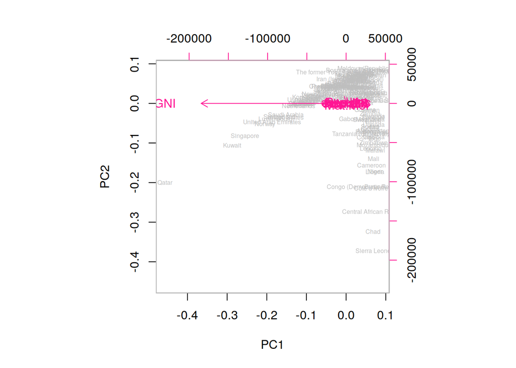

```r
# draw a biplot of the principal component representation and the original variables
biplot(pca_human, choices = 1:2, cex=c(0.5,1), col=c("grey","deeppink"))
```

OK, this doesn’t make sense. **GNI** dominates the model since it has so large scale compared to other ones. Would be against the spirit of statistics to describe this more.

## 3. Standardization and PCA

Standardizing the variables in the human data and repeating the above analysis. Interpreting the results of both analysis (with and without standardizing). Comparing results.

```r
# standardize the variables
human_std <- scale(human)

# print out summaries of the standardized variables
summary(human_std)
```

```
##    edu.ratio         lab.ratio          exp.life          exp.educ
##  Min.   :-2.8189   Min.   :-2.6247   Min.   :-2.7188   Min.   :-2.7378
##  1st Qu.:-0.5233   1st Qu.:-0.5484   1st Qu.:-0.6425   1st Qu.:-0.6782
##  Median : 0.3503   Median : 0.2316   Median : 0.3056   Median : 0.1140
##  Mean   : 0.0000   Mean   : 0.0000   Mean   : 0.0000   Mean   : 0.0000
##  3rd Qu.: 0.5958   3rd Qu.: 0.7350   3rd Qu.: 0.6717   3rd Qu.: 0.7126
##  Max.   : 2.6646   Max.   : 1.6632   Max.   : 1.4218   Max.   : 2.4730
##       GNI             Mat.Mor           Adol.BR           Rep.pct
##  Min.   :-0.9193   Min.   :-0.6992   Min.   :-1.1325   Min.   :-1.8203
##  1st Qu.:-0.7243   1st Qu.:-0.6496   1st Qu.:-0.8394   1st Qu.:-0.7409
##  Median :-0.3013   Median :-0.4726   Median :-0.3298   Median :-0.1403
##  Mean   : 0.0000   Mean   : 0.0000   Mean   : 0.0000   Mean   : 0.0000
##  3rd Qu.: 0.3712   3rd Qu.: 0.1932   3rd Qu.: 0.6030   3rd Qu.: 0.6127
##  Max.   : 5.6890   Max.   : 4.4899   Max.   : 3.8344   Max.   : 3.1850
```

Now each variable has mean 0 and standard deviation (and variance) 1.

```r
# perform principal component analysis (with the SVD method)
pca_human_std <- prcomp(human_std)

pca_human_std
```

```
## Standard deviations (1, .., p=8):
## [1] 2.0708380 1.1397204 0.8750485 0.7788630 0.6619563 0.5363061 0.4589994
## [8] 0.3222406
##
## Rotation (n x k) = (8 x 8):
##                   PC1         PC2         PC3         PC4        PC5
## edu.ratio -0.35664370  0.03796058 -0.24223089  0.62678110 -0.5983585
## lab.ratio  0.05457785  0.72432726 -0.58428770  0.06199424  0.2625067
## exp.life  -0.44372240 -0.02530473  0.10991305 -0.05834819  0.1628935
## exp.educ  -0.42766720  0.13940571 -0.07340270 -0.07020294  0.1659678
## GNI       -0.35048295  0.05060876 -0.20168779 -0.72727675 -0.4950306
## Mat.Mor    0.43697098  0.14508727 -0.12522539 -0.25170614 -0.1800657
## Adol.BR    0.41126010  0.07708468  0.01968243  0.04986763 -0.4672068
## Rep.pct   -0.08438558  0.65136866  0.72506309  0.01396293 -0.1523699
##                   PC6         PC7         PC8
## edu.ratio  0.17713316  0.05773644  0.16459453
## lab.ratio -0.03500707 -0.22729927 -0.07304568
## exp.life  -0.42242796 -0.43406432  0.62737008
## exp.educ  -0.38606919  0.77962966 -0.05415984
## GNI        0.11120305 -0.13711838 -0.16961173
## Mat.Mor    0.17370039  0.35380306  0.72193946
## Adol.BR   -0.76056557 -0.06897064 -0.14335186
## Rep.pct    0.13749772  0.00568387 -0.02306476
```

```r
summary(pca_human_std)
```

```
## Importance of components:
##                           PC1    PC2     PC3     PC4     PC5     PC6     PC7
## Standard deviation     2.0708 1.1397 0.87505 0.77886 0.66196 0.53631 0.45900
## Proportion of Variance 0.5361 0.1624 0.09571 0.07583 0.05477 0.03595 0.02634
## Cumulative Proportion  0.5361 0.6984 0.79413 0.86996 0.92473 0.96069 0.98702
##                            PC8
## Standard deviation     0.32224
## Proportion of Variance 0.01298
## Cumulative Proportion  1.00000
```

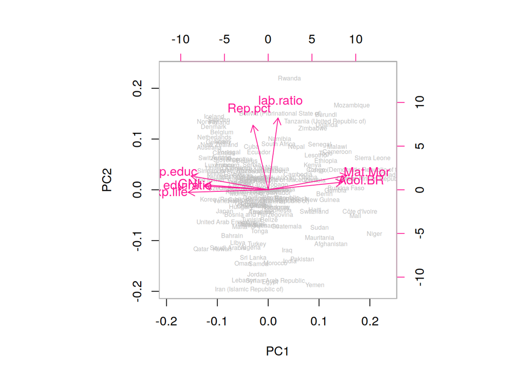

```r
# draw a biplot of the principal component representation and the original variables
biplot(pca_human_std, choices = 1:2, cex=c(0.5,1), col=c("grey","deeppink"))
```

This seems more reasonable, each variables has comparable weight in the analysis.

Unstandardized analysis: GNI dominates the model since it has so large scale compared to other ones. Practically all variability is associated with first principal component (proportion rounds up to 100%).

Standardized analysis: 53% of variance is associated with 1st principal component, 16% with second, 10 % with 3rd etc. Most variables are contributing nicely the first PC, with moderate negative or positive correlations while **Lab.ratio** and **Rep.pct** are not contributing that much.

From the biplot we can see that all variables has somewhat similar arrow size i.e. effect. Most variables are contributing to first PC since arrows are parallel to PC1. Lab.ratio and Rep.pct are almost orthogonal to that, they are associated with PC2.

Both models are conducted with singular value decomposition (SVD) method.

## 4. Interpretation

Personal interpretations of the first two principal component dimensions based on the biplot drawn after PCA on the standardized human data:

So PC1+PC2 explains 54%+16% of total variance.

PC2 is mostly contributed by **lab.ratio** (*Female/male ratio of labour force participation ratios*) and **rep.pct** (*Percent of female representation in Parliament*). This is “positive” factor, which is associated with better gender equality.

Maybe one could summarize all this that PC1 is more about economy and PC2 is about gender equality.

## 5. Multiple corresponsense analysis (MCA)

### My amazing adventures with R #1542: Horrible nightmare with package dependency hell (foul language warning!)

> library(FactoMineR)

*–> "there is no package called ‘FactoMineR’*

Me: “OK, no problem. Let’s install it.”

> install.packages(“FactoMineR”)

–>  
1: In utils::install.packages(“car”, repos = “https://cran.rstudio.com/”) : installation of package ‘nloptr’ had non-zero exit status  
2: In utils::install.packages(“car”, repos = “https://cran.rstudio.com/”) : installation of package ‘lme4’ had non-zero exit status  
3: In utils::install.packages(“car”, repos = “https://cran.rstudio.com/”) : installation of package ‘car’ had non-zero exit status  
4: In utils::install.packages(“FactoMineR”, repos = “https://cran.rstudio.com/”) : installation of package ‘FactoMineR’ had non-zero exit status

Me: “Hmm… no problem. Lets install those missing dependencies first then.”

> install.packages(“car”)

–>  
ERROR: configuration failed for package ‘nloptr’  
ERROR: dependency ‘nloptr’ is not available for package ‘lme4’  
* removing ‘/home/ls/R/x86_64-suse-linux-gnu-library/3.5/lme4’  
Warning in install.packages :  
installation of package ‘lme4’ had non-zero exit status  
ERROR: dependencies ‘pbkrtest’, ‘lme4’ are not available for package ‘car’

Me: “Me:”Well, this is getting akward. But we’ll sort this out. Lets install nloptr first then."

> install.packages(“nloptr”)

–>  
../libtool: line 1102: ERROR:: command not found  
make[2]: *** [Makefile:371: libutil.la] Error 127  
ERROR: configuration failed for package ‘nloptr’

Me: “☠#💩!”

…A lot of surfing around…

Me: “Installing library libnlopt0 into operating system may help.”

**[installing libnlopt0 (A library for nonlinear optimization) with OS software management system]**

> install.packages(“nloptr”)

–>  
../libtool: line 1102: ERROR:: command not found  
make[2]: *** [Makefile:371: libutil.la] Error 127  
ERROR: configuration failed for package ‘nloptr’

Me: "☠#☣%☭!

…more surfing around…

Me: “Installing libnlopt0 may be the key.”

**[installing nlopt-devel (Development files for nlopt) with OS software management system]**

> install.packages(“nloptr”)

It worked! Woohoo!

> install.packages(“lme4”)

Works! Yippee!

> install.packages(“car”)

–> R: *“No way, dude; dependency ‘pbkrtest’ is not available for package ‘car’”.*

> install.packages(“pbkrtest”)

–> R: *“Come on, such package doesn’t even exist!”.*

Me: “☠#☣%☭¤💩!!!”

…still more surfing around…

Me: "Let’s try the trick from https://stackoverflow.com/questions/35207624/package-pbkrtest-is-not-available-for-r-version-3-2-2, with updated package version.

Manual installation of pbkrtest_0.4-7:

> packageurl <- “https://cran.r-project.org/src/contrib/Archive/pbkrtest/pbkrtest_0.4-7.tar.gz” install.packages(packageurl, repos=NULL, type=“source”)

It worked!

> install.packages(“car”)

Works now!!

> install.packages(“FactoMineR”)

And finally this works as well! Victory!!!

```r
library(FactoMineR)
```

```r
#Loading tea data set.
data('tea')

dim(tea)
```

```
## [1] 300  36
```

```r
str(tea)
```

```
## 'data.frame':    300 obs. of  36 variables:
##  $ breakfast       : Factor w/ 2 levels "breakfast","Not.breakfast": 1 1 2 2 1 2 1 2 1 1 ...
##  $ tea.time        : Factor w/ 2 levels "Not.tea time",..: 1 1 2 1 1 1 2 2 2 1 ...
##  $ evening         : Factor w/ 2 levels "evening","Not.evening": 2 2 1 2 1 2 2 1 2 1 ...
##  $ lunch           : Factor w/ 2 levels "lunch","Not.lunch": 2 2 2 2 2 2 2 2 2 2 ...
##  $ dinner          : Factor w/ 2 levels "dinner","Not.dinner": 2 2 1 1 2 1 2 2 2 2 ...
##  $ always          : Factor w/ 2 levels "always","Not.always": 2 2 2 2 1 2 2 2 2 2 ...
##  $ home            : Factor w/ 2 levels "home","Not.home": 1 1 1 1 1 1 1 1 1 1 ...
##  $ work            : Factor w/ 2 levels "Not.work","work": 1 1 2 1 1 1 1 1 1 1 ...
##  $ tearoom         : Factor w/ 2 levels "Not.tearoom",..: 1 1 1 1 1 1 1 1 1 2 ...
##  $ friends         : Factor w/ 2 levels "friends","Not.friends": 2 2 1 2 2 2 1 2 2 2 ...
##  $ resto           : Factor w/ 2 levels "Not.resto","resto": 1 1 2 1 1 1 1 1 1 1 ...
##  $ pub             : Factor w/ 2 levels "Not.pub","pub": 1 1 1 1 1 1 1 1 1 1 ...
##  $ Tea             : Factor w/ 3 levels "black","Earl Grey",..: 1 1 2 2 2 2 2 1 2 1 ...
##  $ How             : Factor w/ 4 levels "alone","lemon",..: 1 3 1 1 1 1 1 3 3 1 ...
```

[output cut: 22 more lines]

```r
summary(tea)
```

```
##          breakfast           tea.time          evening          lunch
##  breakfast    :144   Not.tea time:131   evening    :103   lunch    : 44
##  Not.breakfast:156   tea time    :169   Not.evening:197   Not.lunch:256
##
##
##
##
##
##         dinner           always          home           work
##  dinner    : 21   always    :103   home    :291   Not.work:213
##  Not.dinner:279   Not.always:197   Not.home:  9   work    : 87
##
##
##
##
##
##         tearoom           friends          resto          pub
##  Not.tearoom:242   friends    :196   Not.resto:221   Not.pub:237
##  tearoom    : 58   Not.friends:104   resto    : 79   pub    : 63
##
##
##
##
##
##         Tea         How           sugar                     how
##  black    : 74   alone:195   No.sugar:155   tea bag           :170
##  Earl Grey:193   lemon: 33   sugar   :145   tea bag+unpackaged: 94
##  green    : 33   milk : 63                  unpackaged        : 36
##                  other:  9
##
##
##
##                   where                 price          age        sex
##  chain store         :192   p_branded      : 95   Min.   :15.00   F:178
##  chain store+tea shop: 78   p_cheap        :  7   1st Qu.:23.00   M:122
##  tea shop            : 30   p_private label: 21   Median :32.00
##                             p_unknown      : 12   Mean   :37.05
##                             p_upscale      : 53   3rd Qu.:48.00
##                             p_variable     :112   Max.   :90.00
##
```

[output cut: 25 more lines]

```
##  feminine    :129   Not.sophisticated: 85   No.slimming:255   exciting   :116
##  Not.feminine:171   sophisticated    :215   slimming   : 45   No.exciting:184
##
##
##
##
##
##         relaxing              effect.on.health
##  No.relaxing:113   effect on health   : 66
##  relaxing   :187   No.effect on health:234
##
##
##
##
##
```

Tea data description from FactoMineR package:

*A data frame with 300 rows and 36 columns. Rows represent the individuals, columns represent the different questions. The first 18 questions are active ones, the 19th is a supplementary quantitative variable (the age) and the last variables are supplementary categorical variables.*

Let’s remove supplementary variables, i.e. retain first 18 questions to keep this simple. Number of cases is only 300, so might be good idea to avoid super-complicated models.

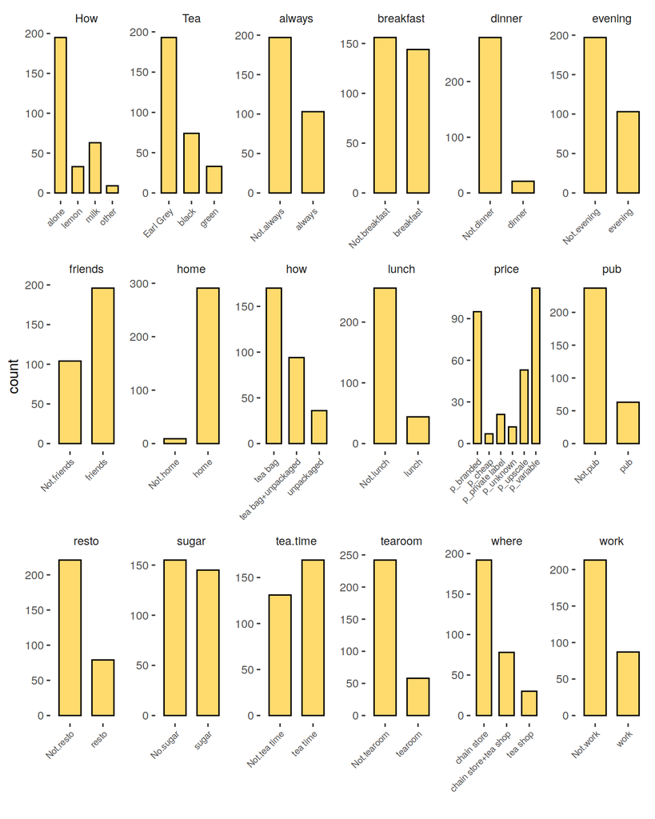

```r
#Using only first "active questions" only
tea2 <- dplyr::select(tea,1:18)

#Barplots for each variable
gather(tea2) %>% ggplot(aes(value)) +
  geom_bar(col="black", fill="#FFDB6D", width=0.667) +
  facet_wrap("key", scales="free", ncol=6) +
  labs(x="") +
  theme(
    axis.text.x=element_text(angle=45, hjust=1, size=7),
    panel.background = element_blank(),
    strip.background = element_blank()
  )
```

### Analysis

```r
# multiple correspondence analysis
mca <- MCA(tea2, graph=FALSE)

# summary of the model
summary(mca)
```

```
##
## Call:
## MCA(X = tea2, graph = FALSE)
##
##
## Eigenvalues
##                        Dim.1   Dim.2   Dim.3   Dim.4   Dim.5   Dim.6   Dim.7
## Variance               0.148   0.122   0.090   0.078   0.074   0.071   0.068
## % of var.              9.885   8.103   6.001   5.204   4.917   4.759   4.522
## Cumulative % of var.   9.885  17.988  23.989  29.192  34.109  38.868  43.390
##                        Dim.8   Dim.9  Dim.10  Dim.11  Dim.12  Dim.13  Dim.14
## Variance               0.065   0.062   0.059   0.057   0.054   0.052   0.049
## % of var.              4.355   4.123   3.902   3.805   3.628   3.462   3.250
## Cumulative % of var.  47.745  51.867  55.769  59.574  63.202  66.664  69.914
##                       Dim.15  Dim.16  Dim.17  Dim.18  Dim.19  Dim.20  Dim.21
## Variance               0.048   0.047   0.046   0.040   0.038   0.037   0.036
## % of var.              3.221   3.127   3.037   2.683   2.541   2.438   2.378
## Cumulative % of var.  73.135  76.262  79.298  81.982  84.523  86.961  89.339
##                       Dim.22  Dim.23  Dim.24  Dim.25  Dim.26  Dim.27
## Variance               0.035   0.031   0.029   0.027   0.021   0.017
## % of var.              2.323   2.055   1.915   1.821   1.407   1.139
## Cumulative % of var.  91.662  93.717  95.633  97.454  98.861 100.000
##
## Individuals (the 10 first)
##                  Dim.1    ctr   cos2    Dim.2    ctr   cos2    Dim.3    ctr
## 1             | -0.541  0.658  0.143 | -0.149  0.061  0.011 | -0.306  0.347
## 2             | -0.361  0.293  0.133 | -0.078  0.017  0.006 | -0.633  1.483
## 3             |  0.073  0.012  0.003 | -0.169  0.079  0.018 |  0.246  0.224
## 4             | -0.572  0.735  0.235 |  0.018  0.001  0.000 |  0.203  0.153
## 5             | -0.253  0.144  0.079 | -0.118  0.038  0.017 |  0.006  0.000
## 6             | -0.684  1.053  0.231 |  0.032  0.003  0.001 | -0.018  0.001
## 7             | -0.111  0.027  0.022 | -0.182  0.090  0.059 | -0.207  0.159
## 8             | -0.210  0.099  0.043 | -0.068  0.013  0.004 | -0.421  0.655
## 9             |  0.118  0.031  0.012 |  0.229  0.144  0.044 | -0.538  1.070
## 10            |  0.258  0.150  0.045 |  0.478  0.627  0.156 | -0.482  0.861
##                 cos2
## 1              0.046 |
## 2              0.409 |
## 3              0.038 |
## 4              0.030 |
```

[output cut: 28 more lines]

```
## dinner         0.535  1.235  0.022  2.537 |
## Not.dinner    -0.040  0.093  0.022 -2.537 |
##
## Categorical variables (eta2)
##                 Dim.1 Dim.2 Dim.3
## breakfast     | 0.025 0.026 0.215 |
## tea.time      | 0.192 0.007 0.054 |
## evening       | 0.053 0.002 0.106 |
## lunch         | 0.075 0.026 0.016 |
## dinner        | 0.033 0.048 0.022 |
## always        | 0.045 0.001 0.101 |
## home          | 0.005 0.000 0.134 |
## work          | 0.112 0.043 0.005 |
## tearoom       | 0.372 0.022 0.008 |
## friends       | 0.243 0.015 0.103 |
```

In the summary output we can see…

**Eigenvalues**: the variances and the percentages of variances retained by each dimension  
- there are 27 dimensions  
- first dimension retains the total variance most, i.e. 9.9%  
- only four first dimensions retains >5% of the variance, total (29.193 %).

**Individuals**: only first 10 individuals (rows) are shown  
- individuals contribution (%) on the dimension is highest on the row2, dimension 3  
- cos2 (squared correlations) on the dimensions is highest again on the row2, dimension 3.

**Categorical variables**:  
- the squared correlations between each variable and dimensions  
- values close to one indicates a strong link with variable and dimension  
- in this table the highest value 0.372 is for “tearoom”.

### Visualization

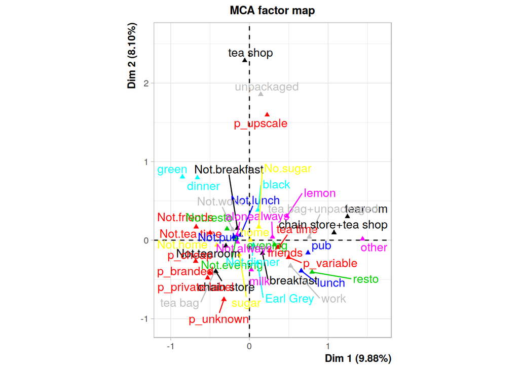

```r
plot(mca, invisible=c("ind"), habillage="quali")
```

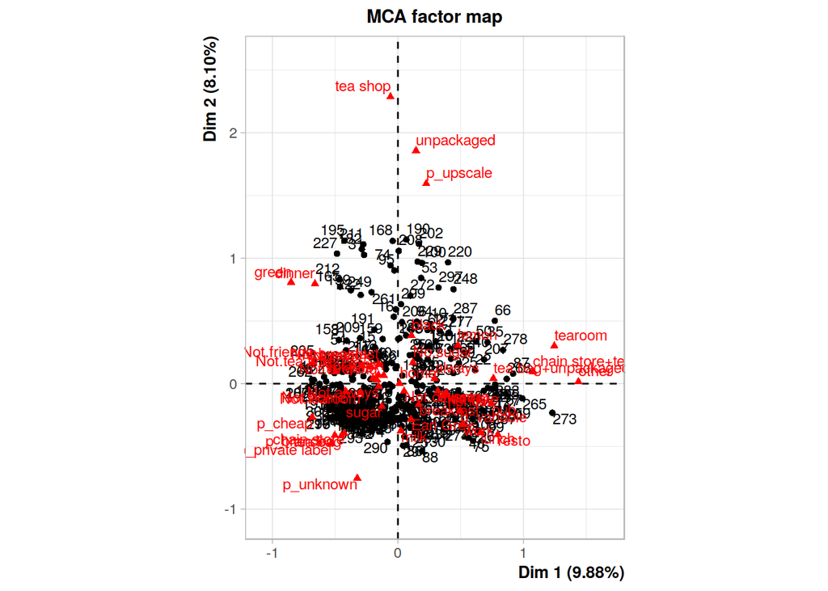

```r
plot(mca,invisible=c("quali.sup","quanti.sup"),cex=0.8)
```

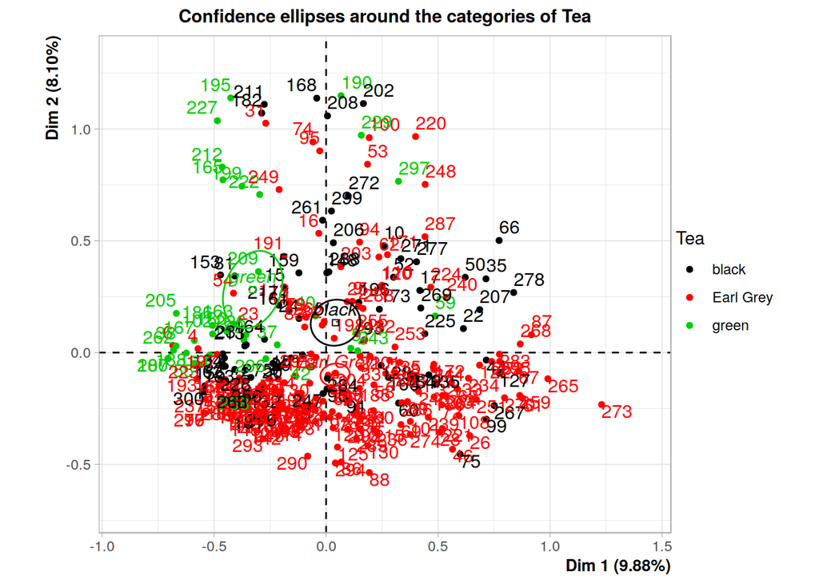

```r
plotellipses(mca,keepvar="Tea")
```

There are various plotting options. I made three different biplots.

Let’s first focus on plot #1. It shows individual variable categories in relation to dimensions 1 and 2. We’ll see that there are three prominent categories:  
- teashop (*tea is purchased merely from tea shop; never from chain store*)  
- tea is unpackaged (*‘never from bag’*)  
- high tea price (*‘p_upscale’*)  
These categories have distinct location on dimension 2, but they are somewhat similar to each other.

Plot #2 shows “individual” as well. We can see, for example that row 273 is a bit different than other cases what comes to location in dimension 1. Otherwise there are no rows that are clearly nonsimilar than other categories.

Plot #3 show individuals in relation to dimensions 1 and 2, but cases are marked with different colors indication tea types (black, Earl Gray, green). We can see that these three groups are are located differently in this 2-dimensional space. Kind of cluster centers are shown with ellipses for these three categories as well.

**Conclusion.** Selecting and drinking tea is complicated and multidimensional phenomenon.